# Simple Regression Extensions - Tasks

Author

Florian Oswald

Published

November 11, 2025

# 1 Task: Wages or Log Wages?

1. install the “wooldridge” package via `install.packages("wooldridge")`. Check out [Jeffrey Wooldridge’s](https://econ.msu.edu/about/directory/wooldridge-jeffrey) website.
2. Make a plot of `wage ~ educ`, and plot the distribution of `wage` alone. What do you observe?

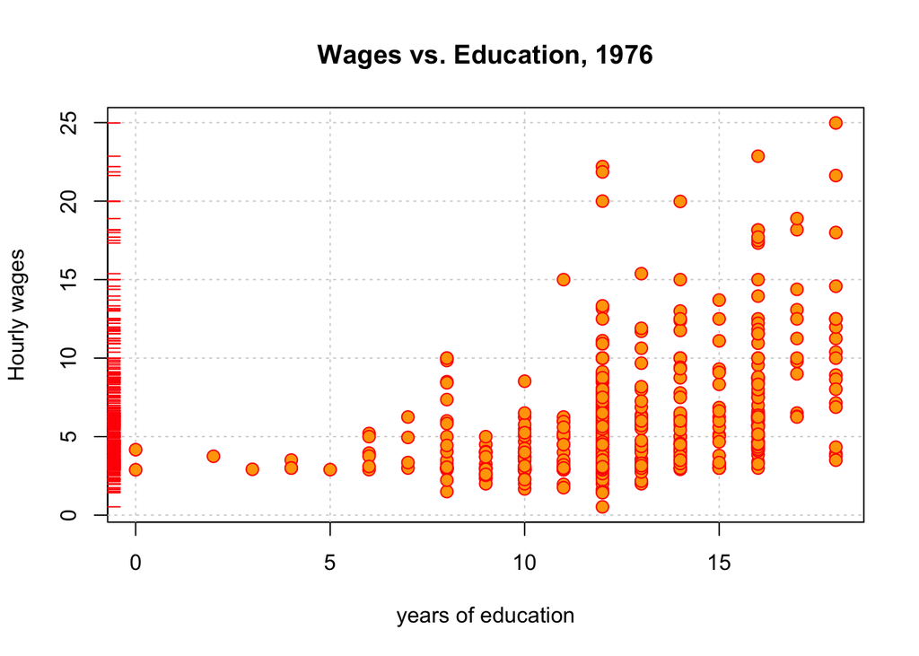

```r
library(tinyplot)
data("wage1", package = "wooldridge")

plt(wage ~ educ, data = wage1,
     col = "red", pch = 21, bg = "orange",
     cex=1.25,grid = TRUE,      # set default x-axis to none
     main = "Wages vs. Education, 1976",
     xlab = "years of education",
     ylab = "Hourly wages")
plt_add(type = "rug", side = 2)
```

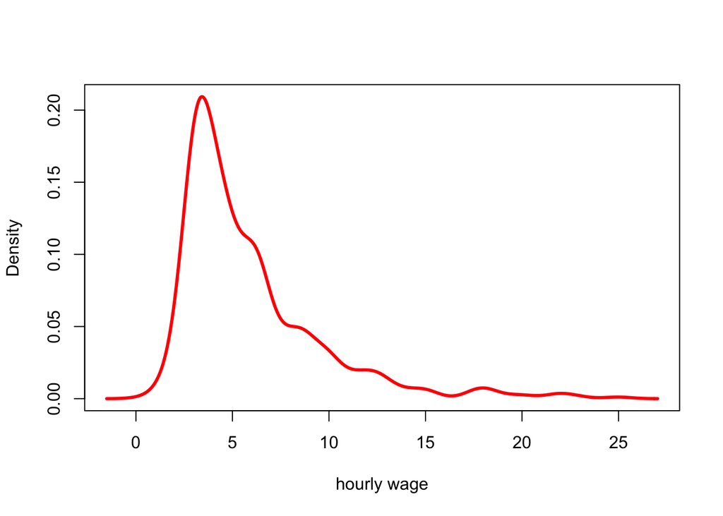

```r
plt(~wage, data = wage1, type = "density", lw = 3, col = "red",xlab = "hourly wage")
```

3. Make the same plot but use `log(wage) ~ educ` as your formula instead. Observe what?

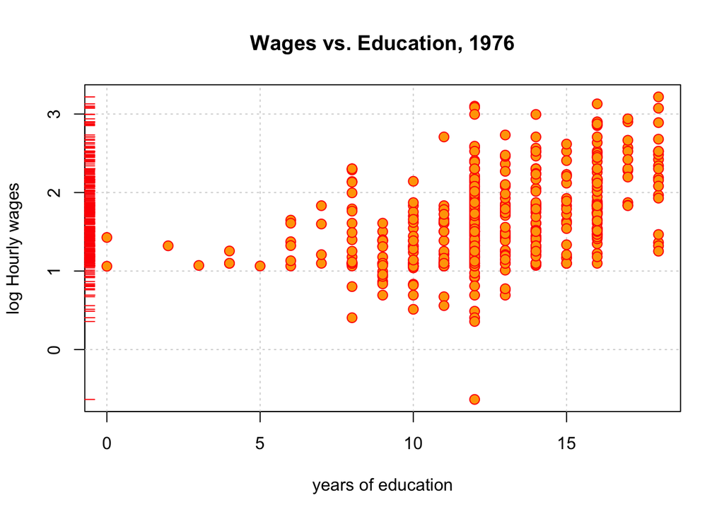

```r
plt(log(wage) ~ educ, data = wage1,
    col = "red", pch = 21, bg = "orange",
    cex=1.25,grid = TRUE,      # set default x-axis to none
    main = "Wages vs. Education, 1976",
    xlab = "years of education",
    ylab = "log Hourly wages")
plt_add(type = "rug", side = 2)
```

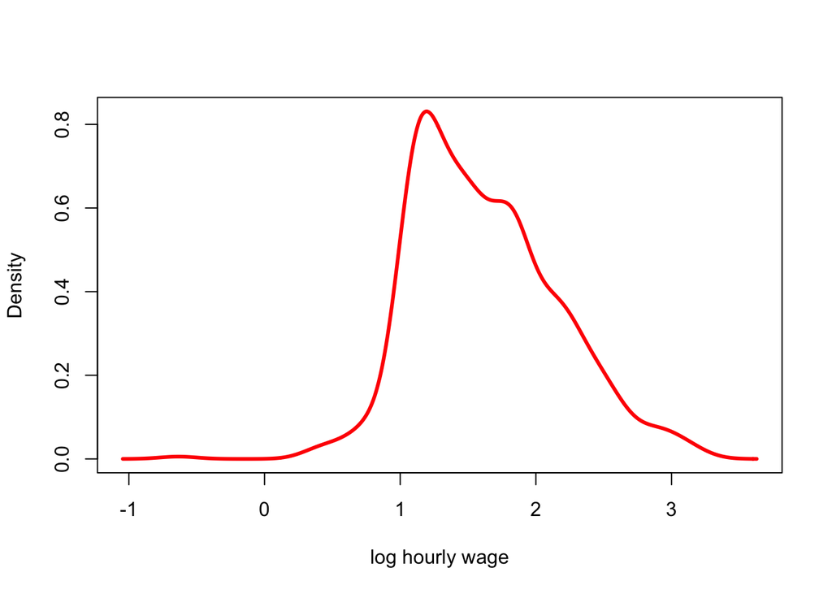

```r
plt(~log(wage), data = wage1, type = "density", lw = 3, col = "red",xlab = "log hourly wage")
```

4. Run 3 regression models: `wage ~ educ, log(wage) ~ educ, log(wage) ~ log(educ)`. Take care with the last model!

```r
mods = list()
mods[["level-level"]] = lm(wage ~ educ , data = wage1)
mods[["log-level"]] = lm(log(wage) ~ educ , data = wage1)
mods[["log-log"]] = lm(log(wage) ~ log(educ) , data = wage1, subset = educ > 0)

modelsummary::modelsummary(mods, gof_map = gm)
```

|  | level-level | log-level | log-log |
| --- | --- | --- | --- |
| (Intercept) | -0.905 | 0.584 | -0.445 |
|  | (0.685) | (0.097) | (0.218) |
| educ | 0.541 | 0.083 |  |
|  | (0.053) | (0.008) |  |
| log(educ) |  |  | 0.825 |
|  |  |  | (0.086) |
| Num.Obs. | 526 | 526 | 524 |
| R2 Adj. | 0.163 | 0.184 | 0.147 |

Interpretation:

- level-level: a 1-year increase in education implies a 0.541 *dollar* increase in the hourly wage.
- log-level: a 1-year increase in education implies a (100 x 0.083) % = 8.3 *percent* increase in the hourly wage.
- log-log: a 1 *percent* increase in education implies a 0.825 *percent* increase in the hourly wage.

# 2 Task: Standardized regression

```r
library(haven)
grades = read_dta(file = "https://www.dropbox.com/s/wwp2cs9f0dubmhr/grade5.dta?dl=1")

reg_full <- lm(avgverb ~ classize + disadvantaged + school_enrollment + female + religious, grades)
reg_full$coefficients
```

```
      (Intercept)          classize     disadvantaged school_enrollment
     78.560725298       0.003320773      -0.389333008       0.000758258
           female         religious
      0.923710499       2.876146701
```

1. Create a new variable `avgmath_stand` equal to the standardized math score. You can use the `scale()` function (combined with `mutate`) or do it by hand with base `R`.

```r
library(tidyverse)
# using scale()
grades <- grades %>%
    mutate(avgmath_stand = scale(avgmath))

# using base R
grades$avgmath_stand_2 <- (grades$avgmath - mean(grades$avgmath)) / sd(grades$avgmath)

identical(grades$avgmath_stand, grades$avgmath_stand_2)
```

```
[1] FALSE
```

2. Run the full regression using the standardized math test score as the dependent variable. Interpret the coefficients and their magnitude.

```r
reg_full_stand <- lm(avgmath_stand ~ classize + disadvantaged + school_enrollment + female + religious, grades)
reg_full_stand$coefficients
```

```
      (Intercept)          classize     disadvantaged school_enrollment
      0.314986346       0.002630553      -0.036187210       0.001911697
           female         religious
     -0.125894281       0.120617503
```

**Interpretation for the class size coefficient: holding all the other regressors included in the regression constant, on average, a 1-student increase in class size is associated with a 0.003 standard deviation increase in average math scores. This is a very small association: 0.3% of a standard deviation.**

3. Create the standardized variables for each *continuous* regressor as `<regressor>_stand`. * Would it make sense to standardize the `religious` variable?

```r
grades <- grades %>%
    mutate(classize_stand = scale(classize),
           disadvantaged_stand = scale(disadvantaged),
           school_enrollment_stand = scale(school_enrollment),
           female_stand = scale(female))
```

**It would not make much sense to standardize the `religious` variable because it is a dummy variable, equal to 1 if the school is religious, and 0 otherwise.**

4. Regress `avgmath_stand` on the full set of standardized regressors and `religious`. Discuss the relative influence of the regressors.

```r
reg_full_stand_2 <- lm(avgmath_stand ~ classize_stand + disadvantaged_stand + school_enrollment_stand + female_stand + religious, grades)
reg_full_stand_2$coefficients
```

```
            (Intercept)          classize_stand     disadvantaged_stand
            -0.02969138              0.01726695             -0.48857857
school_enrollment_stand            female_stand               religious
             0.07421537             -0.01236283              0.12061750
```

**Interpretation for the class size coefficient: holding all the other regressors included in the regression constant, on average, a 1-standard deviation increase in class size (approx 6.5 students) is associated with a 0.02 standard deviation increase in average math scores. This is quite a small association: 2% of a standard deviation. Note that this coefficient can be otained by multiplying the class size coefficient from the previous question’s regression by the approx 6.5 (i.e. 1 standard deviation of the class size variable).**

# 3 Task: Non-linear relationships

1. Load the data [here](https://www.dropbox.com/s/2v5mb04nzw2u7bd/college_tuition_income.csv?dl=1). This dataset contains information about tuition and estimated incomes of graduates for universities in the US. More details can be found [here](https://github.com/rfordatascience/tidytuesday/blob/master/data/2020/2020-03-10/readme.md).

```r
college <- read.csv("https://www.dropbox.com/s/2v5mb04nzw2u7bd/college_tuition_income.csv?dl=1")
```

2. Create a scatter plot of estimated mid career pay (`mid_career_pay`) $(y-axis)$ as a function of out of state tuition (`out_of_state_tuition`) $(x-axis)$. Would you say the relationship is broadly linear or rather non-linear? Use `geom_smooth(method = "lm", se = F) + geom_smooth(method = "lm", se = F, formula = y ~ poly(x, 2, raw= T))` to fit both a linear and 2nd order regression line. This time which seems most appropriate?

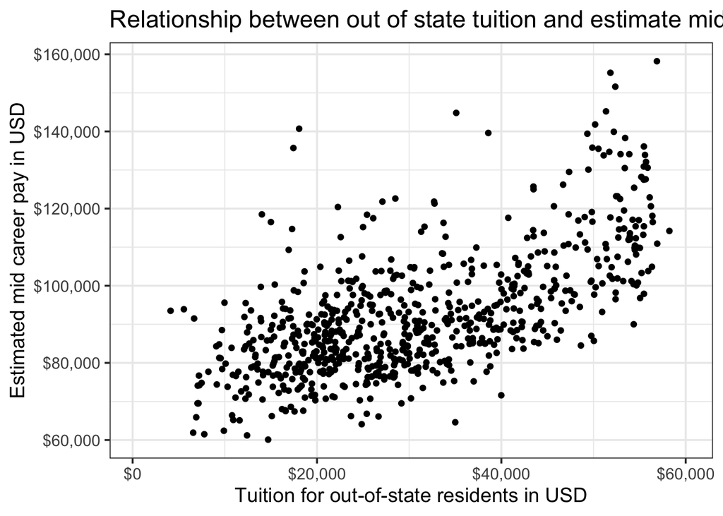

```r
base_graph <- college %>%
    ggplot(aes(x = out_of_state_tuition, y = mid_career_pay)) +
    geom_point() +
    labs(x = "Tuition for out-of-state residents in USD",
         y = "Estimated mid career pay in USD",
         title = "Relationship between out of state tuition and estimate mid career pay") +
    scale_x_continuous(labels = scales::dollar) +
    scale_y_continuous(labels = scales::dollar) +
    theme_bw(base_size = 14)
base_graph
```

**The relationship appears to be relatively linear though there is a some non-linearity at the upper end of the out of state tuition distribution, i.e. on the right-hand side of the graph. A 2nd order or 3rd order polynomial regression may be appropriate to capture it.**

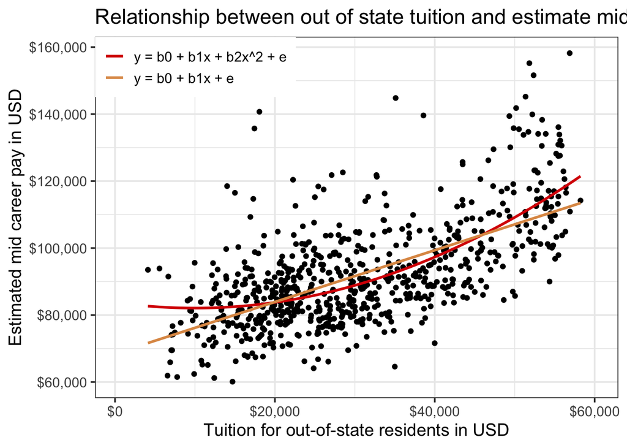

```r
base_graph +
    geom_smooth(method='lm', se = FALSE, formula = y~poly(x,2, raw = T), aes(colour="y = b0 + b1x + b2x^2 + e")) +
    geom_smooth(method='lm', se = FALSE, aes(colour="y = b0 + b1x + e")) +
    scale_colour_manual(name = NULL, values=c("#d90502", "#DE9854")) +
    theme(legend.position = c(0,1),
          legend.justification = c(0,1))
```

**Based on my first impressions, the 2nd order polynomial fit seems to be a bit better at capturing non-linearities to the left and right of the graph.**

3. Create a variable equal to out of state tuition divided by 1000. Regress mid career pay on out of state tuition divided by 1000. Interpret the coefficient.

```r
college <- college %>%
    mutate(out_state = out_of_state_tuition/1000)

lm(mid_career_pay ~ out_state, college)
```

```
Call:
lm(formula = mid_career_pay ~ out_state, data = college)

Coefficients:
(Intercept)    out_state
    68462.4        772.3
```

**On average, a $1,000 increase in out of state tuition is associated with a $772 increase in estimated mid career pay.**

4. Regress mid career pay on out of state tuition divided by 1000 and its square. *Hint:* you can use either `poly(x, 2, raw = T)` or `x + I(x^2)`, where x is your regressor. What does the positive sign on the squared term imply?

```r
lm(mid_career_pay ~ poly(out_state, 2, raw = T), college)
```

```
Call:
lm(formula = mid_career_pay ~ poly(out_state, 2, raw = T), data = college)

Coefficients:
                 (Intercept)  poly(out_state, 2, raw = T)1
                    83769.88                       -338.10
poly(out_state, 2, raw = T)2
                       16.92
```

**The positive sign on the squared term (`poly(out_state, 2, raw = T)2` implies that as out of state tuition increases the increase in estimated mid career pay increases faster. In other words, the slope of the line is increasing in out of state tuition, it becomes steeper as you move to the right of the graph.**

## 3.1 Task: Wages, education and gender in 1985

1. Load the data `CPS1985` from the `AER` package.

```r
library(AER)
data("CPS1985")
cps = CPS1985
```

2. Look at the `help` to get the definition of each variable: `?CPS1985`

```r
?AER::CPS1985
```

3. We don’t know if people are working part-time or full-time, does it matter here?

**It doesn’t matter much since we are analysing hourly wages.**

4. Create the`log_wage` variable equal to the log of `wage`.

```r
cps <- cps %>%
    mutate(log_wage = log(wage))
```

5. Regress `log_wage` on `gender` and `education`, and save it as `reg1`. Interpret each coefficient.

```r
reg1 <- lm(log_wage ~ gender + education, cps)
reg1
```

```
Call:
lm(formula = log_wage ~ gender + education, data = cps)

Coefficients:
 (Intercept)  genderfemale     education
     1.16519      -0.23207       0.07685
```

**This is a log-level regression so the coefficients are interpreted as unit increase in $x$ associated with percent change in $y$. On average, women earn exp(-0.23207) = 0.79 percent of what men earn, holding education constant. That is, controlling for education, women earn on average 21% less than men. Note that since the coefficient is relatively small, you can approximate the interpretation as: on average, women earn 23% less than men with the same level of education.**

**Holding gender constant, a 1-year increase in years of education is associated, on average, with a exp(0.07685) = 1.08 percent change in hourly earnings. In other words, controlling for gender, on average, 1-year increase in years of education is associated with an 8% increase in hourly wage. Again, since the coefficient is quite small you can use the approximation we saw earlier on.**

6. Regress the `log_wage` on `gender`, `education` and their interaction `gender*education`, save it as `reg2`. Interpret each coefficient. Does the gender wage gap decrease with education?

```r
reg2 <- lm(log_wage ~ gender*education, cps)
reg2
```

```
Call:
lm(formula = log_wage ~ gender * education, data = cps)

Coefficients:
           (Intercept)            genderfemale               education
               1.32352                -0.63315                 0.06468
genderfemale:education
               0.03080
```

**On average, men with no education earn exp(1.32352) = 3.76 dollars an hour. Women with no education, on average, earn about exp(-0.63315) = 0.53 47% less than men with no education. On average, for men, 1-year increase in years of education is associated, on average, with a exp(0.06468) = 1.07 percent increase, i.e. a 6.68% increase, in hourly wages. The difference in the return to education between women and men is about exp(0.03080) = 1.03 percentage points, that is for each additional year of educatio, women’s hourly wage increases by about exp(0.06468 + 0.03080) = 1.1, i.e. 10%. Graphically, this means that the slope for women is steeper than that for men. The gender pay gap therefore shrinks with years of education.**

7. Create a plot showing this interaction. (*Hint:* use the `color = gender` argument in `aes` and `geom_smooth(method = "lm", se = F)` to obtain a regression line per gender.)

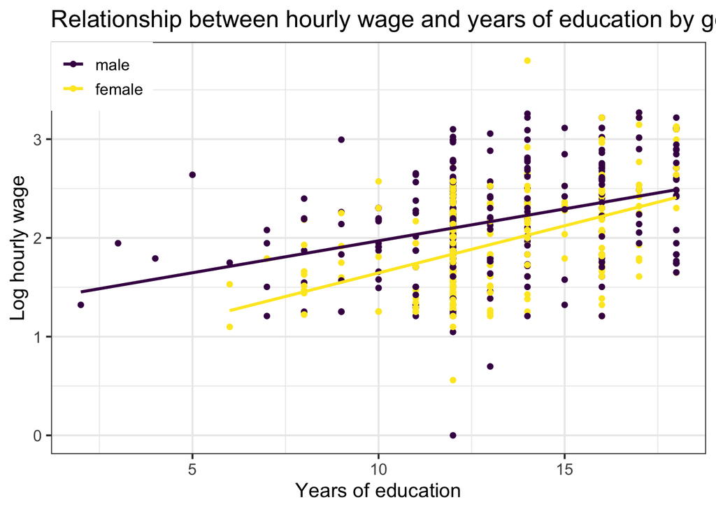

```r
cps %>%
    ggplot(aes(x = education, y = log_wage, col = gender)) +
    geom_point() +
    geom_smooth(method= "lm", se = F) +
    scale_color_viridis_d() +
    labs(x = "Years of education", y = "Log hourly wage", title = "Relationship between hourly wage and years of education by gender", color = NULL) +
    theme_bw(base_size = 14) +
    theme(legend.position = c(0,1),
          legend.justification = c(0,1))
```